# Lab 6 Key

## 1. Study Background

In an experiment, 12 fifth grade students are introduced to a set of vocabulary words by watching a lecture in each of three subject areas: physical science, social science, and history. A vocabulary test with 60 words followed each lecture.

Our research question was: “To what extent does lecture topic influence the vocabulary learning of fifth grade students?”

## 2. Data Preparation

To get the data in a format that is better to work with, `rename()` variables and then use `pivot_longer()` to get data in a format R can use.

```r
needs(tidyverse, rio, here, knitr, kableExtra, misty, janitor, rstatix, psych, misty, MOTE)
lab6_data_raw <- misty::read.sav(here("assignments_data", "Lab6_Vocab.sav"), use.value.labels = TRUE)

head(lab6_data_raw) #what it looks like before
```

```
##   idnum vocab1 vocab2 vocab3
## 1     1     53     47     45
## 2     2     49     42     41
## 3     3     47     39     38
## 4     4     42     37     36
## 5     5     51     42     35
## 6     6     34     33     33
```

```r
lab6_data <- lab6_data_raw %>%
  rename(phys = vocab1,
         soc = vocab2,
         hist = vocab3) %>%
  pivot_longer(cols = c(phys, soc, hist), names_to = "instr", values_to = "vocab_score")

head(lab6_data) #what it looks like when it's clean
```

```
## # A tibble: 6 × 3
##   idnum instr vocab_score
##   <dbl> <chr>       <dbl>
## 1     1 phys           53
## 2     1 soc            47
## 3     1 hist           45
## 4     2 phys           49
## 5     2 soc            42
## 6     2 hist           41
```

## 3. Examining Data and ANOVA Assumptions

```r
str(lab6_data)
```

```
## tibble [36 × 3] (S3: tbl_df/tbl/data.frame)
##  $ idnum      : num [1:36] 1 1 1 2 2 2 3 3 3 4 ...
##   ..- attr(*, "label")= chr "id number"
##  $ instr      : chr [1:36] "phys" "soc" "hist" "phys" ...
##  $ vocab_score: num [1:36] 53 47 45 49 42 41 47 39 38 42 ...
```

```r
lab6_data$instr <- as.factor(lab6_data$instr)
lab6_data$idnum <- as.factor(lab6_data$idnum)
describe(lab6_data)
```

```
##             vars  n mean    sd median trimmed   mad min max range  skew
## idnum*         1 36  6.5  3.50    6.5     6.5  4.45   1  12    11  0.00
## instr*         2 36  2.0  0.83    2.0     2.0  1.48   1   3     2  0.00
## vocab_score    3 36 33.5 12.87   35.5    34.2 12.60   6  53    47 -0.54
##             kurtosis   se
## idnum*         -1.31 0.58
## instr*         -1.58 0.14
## vocab_score    -0.87 2.14
```

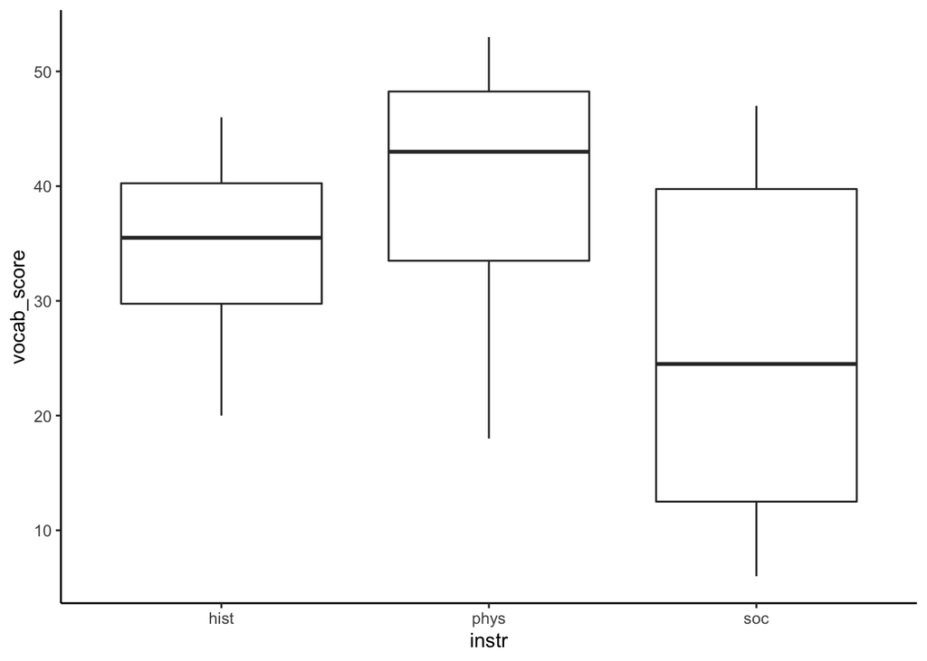

```r
ggplot(data = lab6_data, aes(x = instr, y = vocab_score)) +
  geom_boxplot() +
  theme_classic()
```

Average vocabulary score is 33.5 (sd = 12.87) and is approximately normally distributed (skew and kurtosis < ±2). Average vocabulary score for physical science lecture is about 40 words, social science is 26 words, and history is 34.5 words.

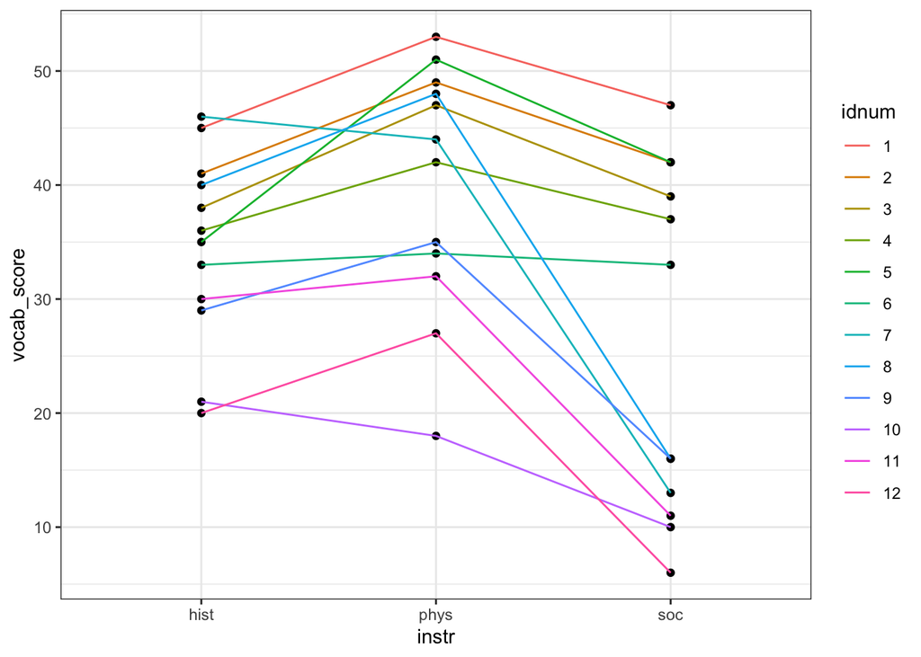

```r
lab6_data %>%
  ggplot(aes(instr, vocab_score, group = idnum)) +
  geom_point() +
  geom_line(aes(color = idnum)) +
  theme_bw()
```

The graph above traces each individual’s scoring, from history to physical science to social science, illustrating the differences between scores for each student.

*Assumptions:*

- Average vocabulary score is 33.5 (sd = 12.87) and is approximately normally distributed (skew and kurtosis < ±2).
- We assume that the inclusion of one participant does not affect the inclusion of another. Participant participation is independent of one another.
- We assume homogeneity of between-subject variance (no need to check this because we have only one IV).
- Sphericity: According to Mauchly’s test below, sphericity assumption is violated since the p-value is .01.

## 4. One-Way Within-Subjects ANOVA

```r
needs(afex)

m1 <- afex::aov_car(vocab_score ~ instr + Error(idnum/instr),
                           data=lab6_data, include_aov = F) ## the correction .63101 affects degrees of freedom. multiply this by the df given to get true df, if needed
summary(m1)
```

```
##
## Univariate Type III Repeated-Measures ANOVA Assuming Sphericity
##
##             Sum Sq num Df Error SS den Df F value    Pr(>F)
## (Intercept)  40401      1   3531.7     11 125.836 2.319e-07 ***
## instr         1194      2   1067.3     22  12.305  0.000259 ***
## ---
## Signif. codes:  0 '***' 0.001 '**' 0.01 '*' 0.05 '.' 0.1 ' ' 1
##
##
## Mauchly Tests for Sphericity
##
##       Test statistic  p-value
## instr        0.41524 0.012345
##
##
## Greenhouse-Geisser and Huynh-Feldt Corrections
##  for Departure from Sphericity
##
##        GG eps Pr(>F[GG])
## instr 0.63101    0.00225 **
## ---
## Signif. codes:  0 '***' 0.001 '**' 0.01 '*' 0.05 '.' 0.1 ' ' 1
##
##          HF eps Pr(>F[HF])
## instr 0.6748954 0.00173583
```

```r
effectsize::omega_squared(m1)
```

```
## # Effect Size for ANOVA (Type III)
##
## Parameter | Omega2 (partial) |       95% CI
## -------------------------------------------
## instr     |             0.18 | [0.00, 1.00]
##
## - One-sided CIs: upper bound fixed at (1).
```

## 5. Post-Hoc Custom Contrasts

We tested the post-hoc hypothesis that students’ average vocabulary scores would be higher in the physical science lecture than from the combined average of social science and history lecture groups. We found evidence to support our post-hoc hypothesis, where students’ vocabulary scores were significantly different comparing the physical science lecture to the other two lecture groups combined (*t* = 6.21, *p* < .001, $\omega^{2}$ = 0.511), accounting for approximately 51.1% of variance in the model. This difference remained statistically significant after correcting for multiple comparisons using a post-hoc Bonferroni adjustment (i.e., $\alpha$ = .05/2 tests = .025). In other words, the vocabulary score for students in the physical science lecture (*M* = 40 words) was significantly higher than the combined average of students in the social science lecture (*M* = 26 words) and history lecture group (*M* = 34.5 words).

```r
needs(emmeans)
em <- emmeans(m1, ~instr)

pairs(em)
```

```
##  contrast    estimate   SE df t.ratio p.value
##  hist - phys     -5.5 1.52 11  -3.618  0.0104
##  hist - soc       8.5 3.59 11   2.368  0.0875
##  phys - soc      14.0 3.01 11   4.651  0.0019
##
## P value adjustment: tukey method for comparing a family of 3 estimates
```

```r
em
```

```
##  instr emmean   SE df lower.CL upper.CL
##  hist    34.5 2.42 11     29.2     39.8
##  phys    40.0 3.12 11     33.1     46.9
##  soc     26.0 4.39 11     16.3     35.7
##
## Confidence level used: 0.95
```

```r
contrasts <- list(hyp1 = c(-.5, 1, -.5))
contrast(em, contrasts)
```

```
##  contrast estimate   SE df t.ratio p.value
##  hyp1         9.75 1.57 11   6.211  0.0001
```

```r
#Calculate effect size with Omega
# First turn t-ratio into F-ratio by squaring it: t^2 = F
(6.211)^2
```

```
## [1] 38.57652
```

```r
# Fvalue = 38.57652

# Second, put in values accordingly:
omega.F(dfm = 1, dfe = 11,
      Fvalue = 38.57652, n = 36, a = .025)
```

```
## $omega
## [1] 0.5107135
##
## $omegalow
## [1] 0.0263071
##
## $omegahigh
## [1] 0.8331292
##
## $dfm
## [1] 1
##
## $dfe
## [1] 11
##
## $F
## [1] 38.57652
##
## $p
## [1] 6.612806e-05
##
## $estimate
## [1] "$\\omega^2$ = 0.51, 97.5\\% CI [0.03, 0.83]"
##
## $statistic
## [1] "$F$(1, 11) = 38.58, $p$ < .001"
```